# CTV HGT using Mash distance for variable and constant locus

- Show All Code
- Hide All Code
- View Source

Author

Lakhansing Pardeshi

Published

December 8, 2025

Pangenome analysis of the carotovoricin (CTV) region shows a constant and variable loci. The tail fiber loci (TFL) is the most variable locus followed by the tail tape measure protein. Below, we explore this variable loci at the pangenome scale.

## Initial setup

```r
suppressPackageStartupMessages(library(tidyverse))
suppressPackageStartupMessages(library(ape))
suppressPackageStartupMessages(library(treeio))
suppressPackageStartupMessages(library(ggtree))
suppressPackageStartupMessages(library(ggbeeswarm))
suppressPackageStartupMessages(library(ggrastr))
suppressPackageStartupMessages(library(cowplot))
suppressPackageStartupMessages(library(patchwork))
suppressPackageStartupMessages(library(ComplexHeatmap))
suppressPackageStartupMessages(library(org.Pectobacterium.spp.pan.eg.db))

rm(list = ls())

source("https://raw.githubusercontent.com/lakhanp1/omics_utils/main/RScripts/utils.R")
source("scripts/utils/config_functions.R")
source("scripts/utils/phylogeny_functions.R")
source("scripts/utils/homology_groups.R")
source("scripts/utils/heatmap_utils.R")
################################################################################
set.seed(124)

confs <- prefix_config_paths(
  conf = suppressWarnings(configr::read.config(file = "project_config.yaml")),
  dir = "."
)

outDir <- paste(confs$analysis$ctv$tfl_hgt$path)

pangenome <- confs$data$pangenomes$pectobacterium.v2$name
panConf <- confs$data$pangenomes[[pangenome]]
panOrgDb <- org.Pectobacterium.spp.pan.eg.db
prophageLenCutoff <- confs$analysis$prophages$cutoff_length
treeMethod <- "core_snp_ml" # ani_upgma, kmer_nj
```

## Import data

```r
sampleInfo <- get_metadata(file = panConf$files$metadata, genus = confs$genus)

sampleInfoList <- as.list_metadata(
  df = sampleInfo, sampleId, sampleName, SpeciesName, strain, nodeLabs, genomeId
)

rawTree <- import_tree(
  confs$analysis$phylogeny[[treeMethod]]$files$tree_rooted,
  phylo = TRUE
)

rawTree <- ape::ladderize(rawTree, right = FALSE)

speciesOrder <- suppressMessages(
  readr::read_tsv(confs$analysis$phylogeny[[treeMethod]]$files$species_order)
) %>%
  dplyr::mutate(order = n():1)

distCophen <- tibble::as_tibble(x = cophenetic.phylo(rawTree), rownames = "r1_genomeId") %>%
  tidyr::pivot_longer(
    cols = -r1_genomeId,
    names_to = "r2_genomeId", values_to = "cophenetic"
  )
```

## Import tail regions and distance tables

Build a pairwise tail loci comparison table

```r
tailRegions <- suppressMessages(
  readr::read_tsv(confs$analysis$ctv$tfl$files$hg_regions)
) %>%
  dplyr::left_join(
    y = dplyr::select(
      sampleInfo, genomeId, SpeciesName, geo_loc_country, collection_year,
      collection_year, nodepath.kmer_nj, host, isolation_source
    ),
    by = "genomeId"
  )

# make unique combinations for ctv regions
tailCombs <- tidyr::expand_grid(
  r1 = tailRegions$regionId, r2 = tailRegions$regionId
) %>%
  dplyr::filter(r1 != r2) %>%
  dplyr::mutate(
    pair = paste(pmin(r1, r2), pmax(r1, r2), sep = ",")
  ) %>%
  dplyr::distinct(pair, .keep_all = TRUE) %>%
  dplyr::select(-pair) %>%
  dplyr::left_join(
    y = dplyr::select(tailRegions, regionId, r1_tail = haplotype),
    by = c("r1" = "regionId")
  ) %>%
  dplyr::left_join(
    y = dplyr::select(tailRegions, regionId, r2_tail = haplotype),
    by = c("r2" = "regionId")
  ) %>%
  dplyr::mutate(
    tail_loci = dplyr::if_else(
      r1_tail == r2_tail, "same", "different"
    )
  )
```

Import Mash distance

```r
tailMash <- suppressMessages(
  readr::read_tsv(
    file = confs$analysis$ctv$tfl$files$mash_dist,
    col_names = c("r1", "r2", "mash_tail", "mash_pval_tail", "hash_tail")
  )
)

conservedMash <- suppressMessages(
  readr::read_tsv(
    file = confs$analysis$ctv$conserved$files$mash_dist,
    col_names = c("r1", "r2", "mash_conserv", "mash_pval_conserved", "hash_conserved")
  )
)
```

Import Jaccard distance from `dashing` tool

```r
import_dashing_matrix <- function(file) {
  dashingDist <- suppressMessages(readr::read_tsv(file = file)) %>%
    dplyr::rename(g1 = "##Names") %>%
    dplyr::rename_with(
      .fn = ~ stringr::str_replace(
        string = .x, pattern = ".*/(g_\\d+\\..*)\\.fasta", replacement = "\\1"
      )
    ) %>%
    dplyr::mutate(
      g1 = stringr::str_replace(
        string = g1, pattern = ".*/(g_\\d+\\..*)\\.fasta", replacement = "\\1"
      )
    ) %>%
    tidyr::pivot_longer(cols = -g1, names_to = "g2", values_to = "distance") %>%
    dplyr::filter(distance != "-") %>%
    dplyr::mutate(
      distance = as.numeric(distance)
    )

  return(
    dplyr::bind_rows(
      dplyr::rename(dashingDist, r1 = g1, r2 = g2),
      dplyr::rename(dashingDist, r1 = g2, r2 = g1)
    )
  )
}

tailDash <- import_dashing_matrix(confs$analysis$ctv$tfl$files$dashing_dist) %>%
  dplyr::rename(dash_tail = distance)

conservedDash <- import_dashing_matrix(confs$analysis$ctv$conserved$files$dashing_dist) %>%
  dplyr::rename(dash_conserv = distance)
```

Combine the data with pairwise tail loci in the pangenome

```r
ctvDist <- dplyr::left_join(
  x = tailCombs, y = tailMash, by = c("r1", "r2")
) %>%
  dplyr::left_join(y = conservedMash, by = c("r1", "r2")) %>%
  dplyr::left_join(y = tailDash, by = c("r1", "r2")) %>%
  dplyr::left_join(y = conservedDash, by = c("r1", "r2")) %>%
  tidyr::separate_wider_delim(
    cols = c(r1, r2), delim = ".",
    names = c("genomeId", "species"), names_sep = "_"
  ) %>%
  dplyr::filter(dplyr::if_all(.cols = starts_with("dist_"), .fns = ~ !is.na(.x))) %>%
  dplyr::select(-starts_with("hash_"))
```

## Analyze Mash distance matrix for all TFLs

```r
combinedDist <- dplyr::left_join(
  x = ctvDist, y = distCophen, by = c("r1_genomeId", "r2_genomeId")
) %>%
  dplyr::mutate(
    species_pair = dplyr::if_else(
      r1_species == r2_species, "intra-species", "inter-species"
    ),
    tail_loci = forcats::fct_relevel(tail_loci, "same"),
    species_pair = forcats::fct_relevel(species_pair, "intra-species")
  ) %>%
  dplyr::filter(
    dplyr::if_all(.cols = c(mash_tail, mash_conserv), .fns = ~ !is.na(.x))
  )

readr::write_tsv(
  x = combinedDist,
  file = paste(outDir, "/conserved_tfl_loci_distances.tab", sep = "")
)

distLongDf <- tidyr::pivot_longer(
  data = dplyr::select(combinedDist, !(contains("_pval") | starts_with("dash"))),
  cols = c(mash_tail, mash_conserv),
  names_to = "locus",
  values_to = "mash"
) |>
  dplyr::mutate(locus = forcats::fct_relevel(.f = locus, "mash_conserv"))
```

### Visualize the distribution of cophenetic distances

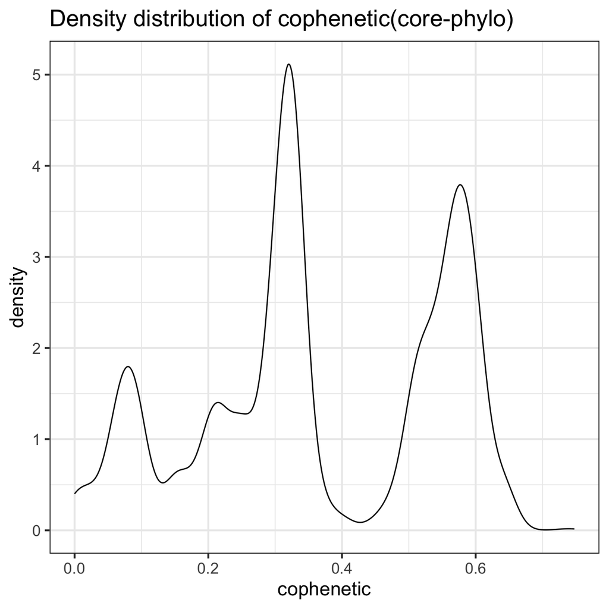

```r
dens_cophn <- ggplot2::ggplot(
  data = combinedDist,
  mapping = aes(x = cophenetic)
) +
  ggplot2::geom_density() +
  ggplot2::labs(
    title = "Density distribution of cophenetic(core-phylo)"
  ) +
  theme_bw(base_size = 16)

dens_cophn
```

### Compare Mash distances distributions between conserved and tail fiber loci

Shapiro-Wilk test to check if the Mash distances are normally distributed:

```r
shapiro.test(x = sample(combinedDist$mash_tail, size = 5000))
```

```
    Shapiro-Wilk normality test

data:  sample(combinedDist$mash_tail, size = 5000)
W = 0.92166, p-value < 2.2e-16
```

```r
shapiro.test(x = sample(combinedDist$mash_conserv, size = 5000))
```

```
    Shapiro-Wilk normality test

data:  sample(combinedDist$mash_conserv, size = 5000)
W = 0.94976, p-value < 2.2e-16
```

The Mash distances are not normally distributed. Therefore, Levene’s test for homogeneity of Mash distance variance across two loci groups (TFL and conserved) is used.

```r
car::leveneTest(mash ~ locus, data = distLongDf)
```

|  | Df | F value | Pr(>F) |
| --- | --- | --- | --- |
| group | 1 | 14550.35 | 0 |
|  | 132858 | NA | NA |

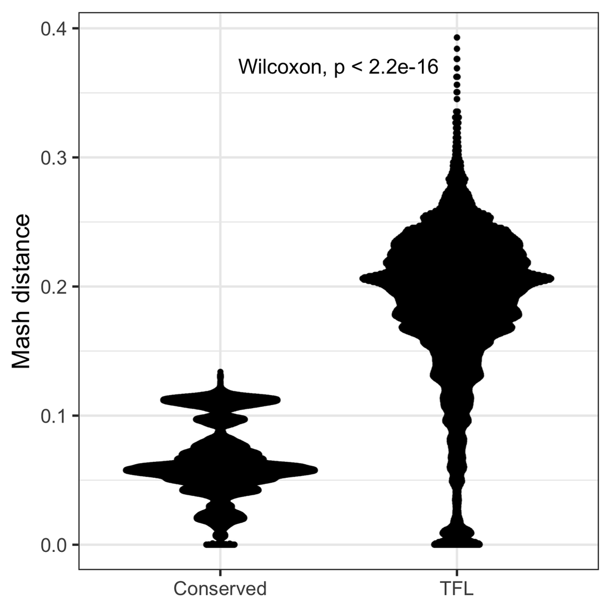

```r
pt_distribution <- ggplot2::ggplot(
  data = distLongDf,
  mapping = aes(x = locus, y = mash)
) +
  ggrastr::rasterize(ggbeeswarm::geom_quasirandom(), dpi = 300) +
  ggpubr::stat_compare_means(
    # method = "wilcox.test", paired = TRUE,
    label.y.npc = 0.9, label.x.npc = "center", vjust = -1, hjust = 0.5, size = 6
  ) +
  labs(y = "Mash distance") +
  scale_x_discrete(
    labels = c("mash_tail" = "TFL", "mash_conserv" = "Conserved")
  ) +
  guides(colour = guide_legend(override.aes = list(size = 5))) +
  theme_bw(base_size = 20) +
  theme(
    # axis.text.x = element_text(angle = 45, hjust = 1, face = "bold.italic"),
    axis.title.x = element_blank()
  )
```

Compare cophenetic distances of core SNP tree with inter-genome Mash distances for CTV loci. Use conserved locus for control and compare with TFL locus.

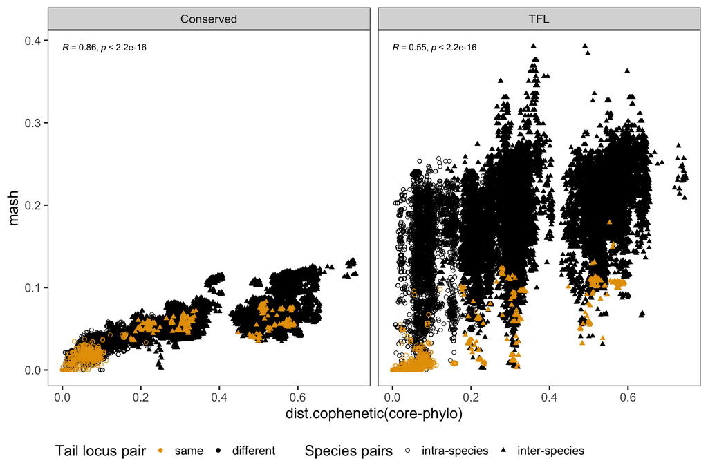

```r
scatter_ctvPhylo <- ggplot2::ggplot(
  data = dplyr::arrange(distLongDf, desc(tail_loci), species_pair),
  mapping = aes(
    x = cophenetic, y = mash
    # x = cophenetic, y = dash,
  )
) +
  ggplot2::geom_point(
    alpha = 1, size = 2,
    mapping = aes(color = tail_loci, shape = species_pair)
  ) +
  ggpubr::stat_cor(label.x.npc = 0, label.y.npc = 1, hjust = 0) +
  ggplot2::labs(
    x = "dist.cophenetic(core-phylo)",
  ) +
  ggplot2::scale_shape_manual(
    values = c("intra-species" = 1, "inter-species" = 17),
    name = "Species pairs"
  ) +
  ggplot2::scale_color_manual(
    values = c("same" = "#E69F00", "different" = "black"),
    name = "Tail locus pair"
  ) +
  ggplot2::facet_wrap(
    facets = ~locus, nrow = 1,
    labeller = ggplot2::as_labeller(
      x = c("mash_tail" = "TFL", "mash_conserv" = "Conserved")
    )
  ) +
  ggplot2::theme_bw(base_size = 18) +
  ggplot2::theme(
    legend.position = "bottom",
    legend.justification = c(0, 1),
    panel.grid = element_blank()
  )
```

Compare the pairwise genomic Mash distance between conserved CTV loci vs TFL loci.

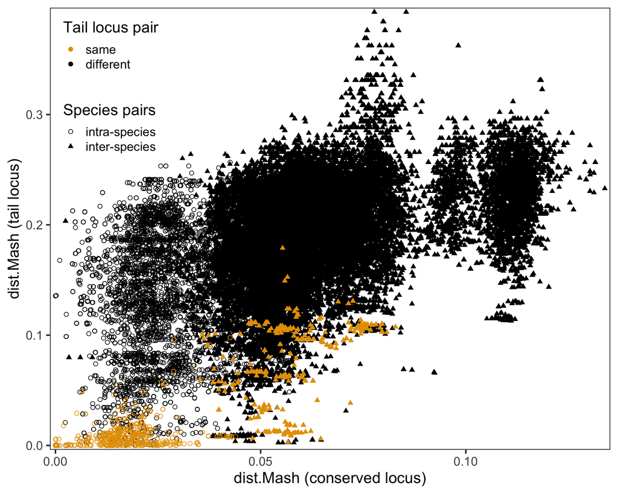

```r
scatter_tailConserved <- ggplot2::ggplot(
  data = dplyr::arrange(combinedDist, desc(tail_loci), species_pair)
) +
  ggplot2::geom_point(
    mapping = aes(
      x = mash_conserv, y = mash_tail,
      # x = dash_conserv, y = dash_tail,
      color = tail_loci, shape = species_pair
    ),
    alpha = 1, size = 2
  ) +
  scale_x_continuous(expand = expansion(0.01)) +
  scale_y_continuous(expand = expansion(0.01)) +
  # geom_abline(slope = 1, color = "red", linetype = "dashed", linewidth = 1) +
  ggplot2::labs(
    x = "dist.Mash (conserved locus)",
    y = "dist.Mash (tail locus)"
  ) +
  ggplot2::scale_shape_manual(
    values = c("intra-species" = 1, "inter-species" = 17),
    name = "Species pairs"
  ) +
  ggplot2::scale_color_manual(
    values = c("same" = "#E69F00", "different" = "black"),
    name = "Tail locus pair"
  ) +
  ggplot2::theme_bw(base_size = 18) +
  ggplot2::theme(
    legend.position = c(0.01, 0.99),
    legend.justification = c(0, 1),
    # plot.margin = unit(c(0, 0, 0, 0), units = "cm"),
    panel.grid = element_blank()
  )

# sideTheme <- theme_void() +
#   theme(
#     legend.position = "none",
#     # plot.margin = unit(c(0, 0, 0, 0), units = "cm"),
#     panel.background = element_rect(color = "black", linewidth = 1)
#   )
#
# xplot <-  ggplot2::ggplot(data = combinedDist) +
#   ggplot2::geom_density(
#     mapping = aes(x = mash_conserv, linetype = species_pair), linewidth = 1
#   ) +
#   scale_x_continuous(expand = expansion(0.01)) +
#   scale_linetype_manual(
#     values = c("intra-species" = 1, "inter-species" = 2)
#   ) +
#   sideTheme
#
# yplot <- ggplot2::ggplot(data = combinedDist) +
#   ggplot2::geom_density(
#     mapping = aes(y = mash_tail, linetype = species_pair), linewidth = 1
#   ) +
#   scale_y_continuous(expand = expansion(0.01)) +
#   scale_linetype_manual(
#     values = c("intra-species" = 2, "inter-species" = 1)
#   ) +
#   sideTheme
#
# ggpubr::ggarrange(
#   xplot, NULL, scatter_tailConserved, yplot,
#   ncol = 2, nrow = 2, align = "hv",
#   widths = c(5, 1), heights = c(1, 5)
# )
```

Inter-species TFLs with smaller Mash distance:

| r1_tail | r2_tail | n |
| --- | --- | --- |
| haplotype_2 | haplotype_10 | 207 |
| haplotype_2 | haplotype_2 | 114 |
| haplotype_1 | haplotype_9 | 98 |
| haplotype_2 | haplotype_24 | 72 |
| haplotype_2 | haplotype_34 | 69 |
| haplotype_3 | haplotype_17 | 45 |
| haplotype_3 | haplotype_51 | 38 |
| haplotype_3 | haplotype_3 | 37 |
| haplotype_10 | haplotype_24 | 29 |
| haplotype_2 | haplotype_15 | 28 |

[output cut: 202 more lines]

## Process conserved and TFL region phylogenetic trees

Tree generated from the region upstream of carotovoricin cluster locus.

```r
upstreamTree <- treeio::read.newick(
  file.path(confs$analysis$ctv$tfl_hgt$path, "iqtree", "genomeset_1_upstream_core.msa.fasta.treefile"),
  node.label = "support"
)

pt_upstream_tree <- ggtree::ggtree(tr = upstreamTree, size = 1.5) +
  scale_x_continuous(expand = expansion(mult = c(0.02, 0.2))) +
  geom_treescale(
    x = 0, y = length(upstreamTree@phylo$tip.label) * 0.8,
    fontsize = 8, linesize = 2, offset = 0.5
  ) +
  ggtree::geom_tiplab(
    mapping = aes(label = label),
    size = 5, align = TRUE, linesize = 1
  ) +
  ggtree::geom_nodelab(
    mapping = aes(label = support),
    node = "internal", size = 5, hjust = 1.3, vjust = -1, color = "red"
  )
```

Conserved locus tree:

```r
conservedTree <- treeio::read.newick(
  file.path(confs$analysis$ctv$tfl_hgt$path, "iqtree", "genomeset_1_conserved.msa.fasta.treefile"),
  node.label = "support"
) |>
  dplyr::left_join(
    y = dplyr::select(tailRegions, label = regionId, haplotype),
    by = "label"
  )


pt_conserved_tree <- ggtree::ggtree(tr = conservedTree, size = 1.5) +
  scale_x_continuous(expand = expansion(mult = c(0.02, 0.3))) +
  ggtree::geom_treescale(
    x = 0, y = length(conservedTree@phylo$tip.label) * 0.8,
    fontsize = 5, linesize = 2, offset = 0.5
  ) +
  ggtree::geom_tiplab(
    mapping = aes(label = label),
    size = 3, align = TRUE, linesize = 0.7
  ) +
  ggtree::geom_nodelab(
    mapping = aes(label = support),
    node = "internal", size = 3, hjust = 1.3, vjust = -1, color = "red"
  ) +
  ggtree::geom_tippoint(mapping = aes(color = haplotype), size = 2) +
  theme(legend.position = "bottom")

# pt_conserved_tree
```

Tail-fiber locus tree:

```r
tflTree <- treeio::read.newick(
  file.path(confs$analysis$ctv$tfl_hgt$path, "iqtree", "genomeset_1_tfl.msa.fasta.treefile"),
  node.label = "support"
) |>
  dplyr::left_join(
    y = dplyr::select(tailRegions, label = regionId, haplotype),
    by = "label"
  )

pt_tfl_tree <- ggtree::ggtree(tr = tflTree, size = 1) +
  scale_x_reverse(expand = expansion(mult = c(0.3, 0.02))) +
  ggtree::geom_treescale(
    x = 0, y = length(tflTree@phylo$tip.label) * 0.8,
    fontsize = 5, linesize = 2, offset = 0.5
  ) +
  ggtree::geom_tiplab(
    mapping = aes(label = label),
    size = 3, align = TRUE, linesize = 0.7, hjust = 1
  ) +
  ggtree::geom_nodelab(
    mapping = aes(label = support),
    node = "internal", size = 3, hjust = -0.5, vjust = -1, color = "red"
  ) +
  ggtree::geom_tippoint(mapping = aes(color = haplotype), size = 2) +
  theme(legend.position = "bottom")

# pt_tfl_tree
```

Combine the conserved and TFL trees for comparison

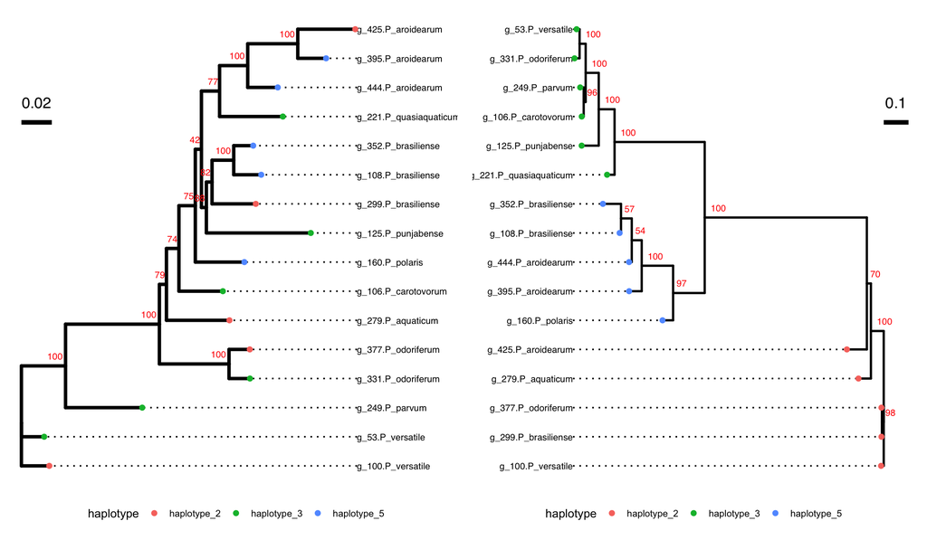

Back to top